# Reporting: Counts, Frequency, etc.

# Background

The final step in the analysis of flow cytometry data is **Reporting**. Below, we show how we can quickly extract counts, frequencies, and expression values for their population(s) of interest.

```r
library(flowCore)
library(flowWorkspace)
library(ggcyto)
```

## Counts, Frequencies, and MFI

We can easily extract Counts and Frequencies of the gated cell population from the `GatingSet`.

```r
# get count for all
counts <- gs_pop_get_count_fast(gs,  # indicate which GatingSet to use
                                statistic = "count", # indicate what statistic is requested
                                format = "wide") # indicate if data should be in wide (samples are columns) or long (each node for each sample gets a row) format

knitr::kable(head(counts,20), caption = "Event counts")
```

Event counts

|  | 4000_TNK-CR1 | 4001_TNK-CR1 | 4002_TNK-CR1 | 4003_TNK-CR1 |
| --- | --- | --- | --- | --- |
| /singlet | 90201 | 82095 | 334739 | 128359 |
| /singlet/live | 85691 | 77990 | 318002 | 121941 |
| /singlet/live/lymphocytes | 79632 | 72217 | 290836 | 113559 |
| /singlet/live/lymphocytes/CD3+ T cells | 67477 | 57833 | 241125 | 80699 |
| /singlet/live/lymphocytes/CD3+ T cells/NKT cells | 5 | 112 | 477 | 75 |
| /singlet/live/lymphocytes/CD3+ T cells/non-NKT Cells | 64774 | 55223 | 237368 | 80040 |
| /singlet/live/lymphocytes/CD3+ T cells/non-NKT Cells/conv_Tcells | 61996 | 52005 | 228635 | 78791 |
| /singlet/live/lymphocytes/CD3+ T cells/non-NKT Cells/conv_Tcells/MAIT Cells | 461 | 738 | 1649 | 640 |
| /singlet/live/lymphocytes/CD3+ T cells/non-NKT Cells/conv_Tcells/not_MAIT | 61535 | 51267 | 226986 | 78151 |
| /singlet/live/lymphocytes/CD3+ T cells/non-NKT Cells/conv_Tcells/not_MAIT_Polygon | 61578 | 51270 | 226928 | 78154 |
| /singlet/live/lymphocytes/CD3+ T cells/non-NKT Cells/conv_Tcells/not_MAIT_Polygon/CD4+CD8a+ | 333 | 79 | 343 | 99 |
| /singlet/live/lymphocytes/CD3+ T cells/non-NKT Cells/conv_Tcells/not_MAIT_Polygon/CD4+CD8a- | 39884 | 35776 | 138031 | 56808 |
| /singlet/live/lymphocytes/CD3+ T cells/non-NKT Cells/conv_Tcells/not_MAIT_Polygon/CD4-CD8a+ | 20283 | 14674 | 85356 | 20771 |
| /singlet/live/lymphocytes/CD3+ T cells/non-NKT Cells/conv_Tcells/not_MAIT_Polygon/CD4-CD8a- | 1078 | 741 | 3198 | 476 |
| root | 102015 | 92703 | 372224 | 146150 |

Changing `statistic` to `freq` return frequency of the gated population with respect to the parent population.

```r
freq <- gs_pop_get_count_fast(gs,
                              statistic = "freq",
                              format = "wide")
knitr::kable(head(freq,20), caption = "Event frequencies relative to parent node")
```

Event frequencies relative to parent node

|  | 4000_TNK-CR1 | 4001_TNK-CR1 | 4002_TNK-CR1 | 4003_TNK-CR1 |
| --- | --- | --- | --- | --- |
| /singlet | 0.8841935 | 0.8855700 | 0.8992945 | 0.8782689 |
| /singlet/live | 0.9500006 | 0.9499970 | 0.9499999 | 0.9499996 |
| /singlet/live/lymphocytes | 0.9292925 | 0.9259777 | 0.9145729 | 0.9312618 |
| /singlet/live/lymphocytes/CD3+ T cells | 0.8473604 | 0.8008225 | 0.8290755 | 0.7106350 |
| /singlet/live/lymphocytes/CD3+ T cells/NKT cells | 0.0000741 | 0.0019366 | 0.0019782 | 0.0009294 |
| /singlet/live/lymphocytes/CD3+ T cells/non-NKT Cells | 0.9599419 | 0.9548701 | 0.9844189 | 0.9918339 |
| /singlet/live/lymphocytes/CD3+ T cells/non-NKT Cells/conv_Tcells | 0.9571124 | 0.9417272 | 0.9632090 | 0.9843953 |
| /singlet/live/lymphocytes/CD3+ T cells/non-NKT Cells/conv_Tcells/MAIT Cells | 0.0074360 | 0.0141909 | 0.0072124 | 0.0081228 |
| /singlet/live/lymphocytes/CD3+ T cells/non-NKT Cells/conv_Tcells/not_MAIT | 0.9925640 | 0.9858091 | 0.9927876 | 0.9918772 |
| /singlet/live/lymphocytes/CD3+ T cells/non-NKT Cells/conv_Tcells/not_MAIT_Polygon | 0.9932576 | 0.9858667 | 0.9925340 | 0.9919153 |
| /singlet/live/lymphocytes/CD3+ T cells/non-NKT Cells/conv_Tcells/not_MAIT_Polygon/CD4+CD8a+ | 0.0054078 | 0.0015409 | 0.0015115 | 0.0012667 |
| /singlet/live/lymphocytes/CD3+ T cells/non-NKT Cells/conv_Tcells/not_MAIT_Polygon/CD4+CD8a- | 0.6476989 | 0.6977960 | 0.6082590 | 0.7268726 |
| /singlet/live/lymphocytes/CD3+ T cells/non-NKT Cells/conv_Tcells/not_MAIT_Polygon/CD4-CD8a+ | 0.3293871 | 0.2862103 | 0.3761369 | 0.2657701 |
| /singlet/live/lymphocytes/CD3+ T cells/non-NKT Cells/conv_Tcells/not_MAIT_Polygon/CD4-CD8a- | 0.0175063 | 0.0144529 | 0.0140926 | 0.0060905 |
| root | 1.0000000 | 1.0000000 | 1.0000000 | 1.0000000 |

What if one wants to report frequencies relative to a different population?

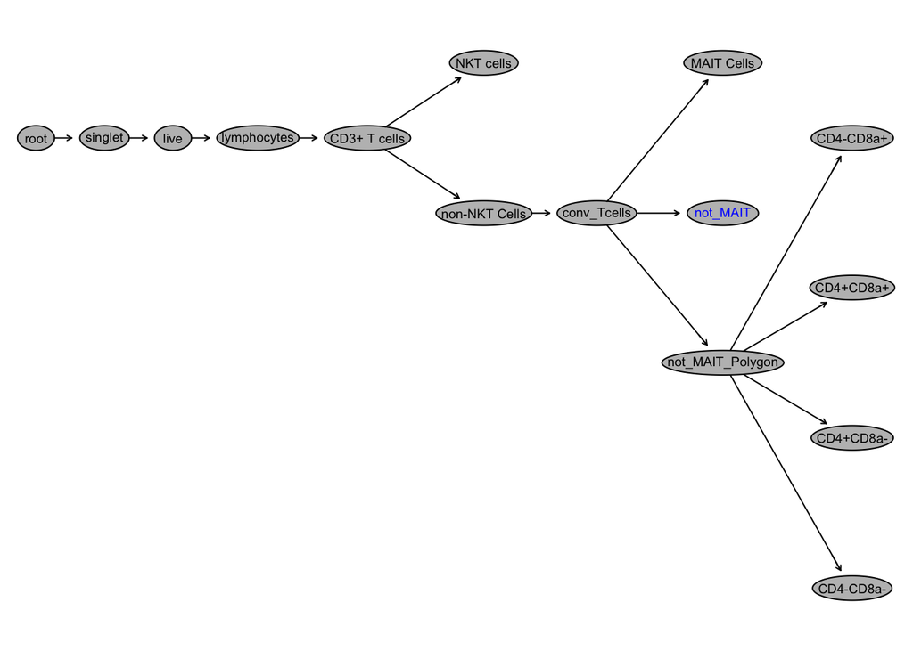

```r
plot(gs, bool = TRUE)
```

Let’s consider the scenario here: you would like to calculate the frequency of **MAIT Cells**, and **True_NKT Cells** relative to total **CD3+ Cells**.

We can easily achieve this by using `gs_pop_get_stats` and indicating which node(s) we want

```r
library(magrittr)
# get count for specified nodes and make wider
pop_counts <- gs_pop_get_stats(gs,
                                    node = c("CD3+ T cells","MAIT Cells", "NKT cells"),
                                    type = "count"
                                    ) %>% # output is a long column
  tidyr::pivot_wider(names_from = pop,
                     values_from = count,names_prefix = "count_") %>% # convert to wide
  dplyr::mutate(MAIT_freq = `count_MAIT Cells`/`count_CD3+ T cells`,
         NKT_freq = `count_NKT cells`/`count_CD3+ T cells`)


knitr::kable(pop_counts,caption = "Frequency of MAIT and NKT Cells (relative to CD3+ T Cells)")
```

Frequency of MAIT and NKT Cells (relative to CD3+ T Cells)

| sample | count_CD3+ T cells | count_MAIT Cells | count_NKT cells | MAIT_freq | NKT_freq |
| --- | --- | --- | --- | --- | --- |
| 4000_TNK-CR1 | 67477 | 461 | 5 | 0.0068320 | 0.0000741 |
| 4001_TNK-CR1 | 57833 | 738 | 112 | 0.0127609 | 0.0019366 |
| 4002_TNK-CR1 | 241125 | 1649 | 477 | 0.0068388 | 0.0019782 |
| 4003_TNK-CR1 | 80699 | 640 | 75 | 0.0079307 | 0.0009294 |

Another common statistic that is reported if MFI (median fluorescence intensity). To extract MFI, we can again make use of `gs_pop_get_stat`. It is important to realize that MFI is often reported in *raw/linear scale*.

```r
mfi_dataframe <- gs_pop_get_stats(gs,
                 nodes = c("CD3+ T cells", "MAIT Cells", "CD4+CD8a-", "CD4-CD8a+"),
                 type = pop.MFI,
                 inverse.transform = TRUE)

mfi_dataframe[1:5, 1:5]
```

```
         sample          pop TCR Vd1 FITC CD127 BB630 PD1 BB660
1: 4000_TNK-CR1 CD3+ T cells     255.0227   1072.3564  142.1997
2: 4000_TNK-CR1   MAIT Cells     273.8928   2158.7324  557.8886
3: 4000_TNK-CR1    CD4+CD8a-     243.4144   1254.2268  139.9552
4: 4000_TNK-CR1    CD4-CD8a+     266.7055    856.4607  121.5325
5: 4001_TNK-CR1 CD3+ T cells     227.1721    626.4796  133.4854
```

For convenience, MFI are extracted for all markers for each of the specified population.

## A simple report

In the table above, we noticed that expression of **PD1** is higher in MAIT Cells. Below, we create 2 plots to help drive this point (if this is of interest). We will make use of `ggcyto` and `ggplot2`

### Boxplot

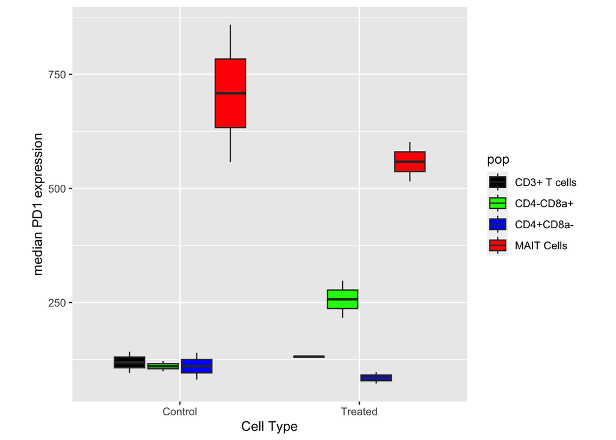

```r
# plot some data
pd1_mfi_plot <- dplyr::left_join(pData(gs),mfi_dataframe,
          by = c("name" = "sample")) %>%
  ggplot(aes(x = mock_treatment, y = `PD1 BB660`, fill = pop))+
  geom_boxplot()+
  labs(x = "Cell Type", y = "median PD1 expression")+
  scale_fill_manual(values = c("CD3+ T cells" = "black",
                               "MAIT Cells" = "red",
                               "CD4+CD8a-" = "blue",
                               "CD4-CD8a+" = "green"),
                    )+
  theme(aspect.ratio = 1,
        legend.position = "right")

pd1_mfi_plot
```

### Overlaid histogram

```r
pd1_overlay <- ggcyto(gs,
       subset = "MAIT Cells",
       aes(x = "PD1"))+
  geom_density(fill = "red", alpha = 0.3)+ # MAIT Cells in red
  geom_overlay(
    data = gs_pop_get_data(gs,"CD3+ T cells"),
    fill = "black", alpha = 0.5)+ # CD3+ Cells in black
   geom_overlay(
    data = gs_pop_get_data(gs,"CD4+CD8a-"),
    fill = "blue", alpha = 0.5)+ # CD4+ T Cells in blue
   geom_overlay(
    data = gs_pop_get_data(gs,"CD4-CD8a+"),
    fill = "green", alpha = 0.5)+ # CD8+ T Cells in green
  axis_x_inverse_trans()+
  facet_wrap(mock_treatment~name, nrow = 1)+
  labs(title = "",x = "PD1")+
  theme(aspect.ratio = 1)
pd1_overlay <- as.ggplot(pd1_overlay)
```

### Final Figure

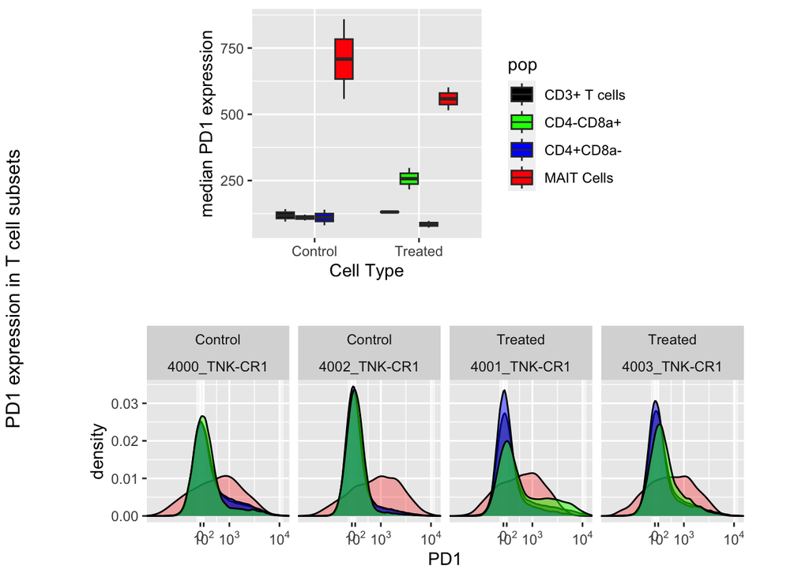

```r
gridExtra::grid.arrange(
 pd1_mfi_plot,
 pd1_overlay,
 nrow = 2,
 left = "PD1 expression in T cell subsets"
)
```

It is now clear that the expression of PD1 indeed tends to be higher on MAIT Cells compared to non-MAIT T Cells.

## (Optional) Additional statistics

It is also possible to calculate additional statistics for the population of interest. For instance, if you were interested in nth percentile expression of a specific marker you could define a function and use it in `gs_pop_get_stats` like so:

```r
# define a function
my_quantile <- function(fr,percentile,chnl){
  matched_chnl <- flowCore::getChannelMarker(fr,chnl) # match channel name
  res <- apply(exprs(fr)[,matched_chnl[["name"]],drop = FALSE], 2, quantile,percentile) # get quantile for specific channel
  names(res) <- matched_chnl[["desc"]]
  return(res)
}

# get stats
median_cd4 <- gs_pop_get_stats(gs,
                 c("lymphocytes","CD3+ T cells","CD4+CD8a-","CD4-CD8a+"),
                 type = my_quantile,
                 inverse.transform = TRUE,
                 stats.fun.arg = list(percentile = .5,
                                      chnl = "cd4"))
knitr::kable(median_cd4,caption = "Median expression of CD4 extracted using user defined function")
```

Median expression of CD4 extracted using user defined function

| sample | pop | CD4 BUV805 |
| --- | --- | --- |
| 4000_TNK-CR1 | lymphocytes | 1043.205715 |
| 4000_TNK-CR1 | CD3+ T cells | 1393.012354 |
| 4000_TNK-CR1 | CD4+CD8a- | 1866.839339 |
| 4000_TNK-CR1 | CD4-CD8a+ | 3.203119 |
| 4001_TNK-CR1 | lymphocytes | 873.184795 |
| 4001_TNK-CR1 | CD3+ T cells | 1366.918737 |
| 4001_TNK-CR1 | CD4+CD8a- | 1805.953805 |
| 4001_TNK-CR1 | CD4-CD8a+ | 4.153675 |
| 4002_TNK-CR1 | lymphocytes | 328.090372 |
| 4002_TNK-CR1 | CD3+ T cells | 959.012183 |
| 4002_TNK-CR1 | CD4+CD8a- | 1401.996476 |
| 4002_TNK-CR1 | CD4-CD8a+ | -8.668585 |
| 4003_TNK-CR1 | lymphocytes | 785.155278 |
| 4003_TNK-CR1 | CD3+ T cells | 1486.741756 |
| 4003_TNK-CR1 | CD4+CD8a- | 1758.953449 |
| 4003_TNK-CR1 | CD4-CD8a+ | -9.211168 |

As we see, we were able to extract median expression of the marker **CD4** on 4 different populations. As expected, expression is highest on **CD4+ T Cells** and lowest on **CD8+ T Cells**.

# Conclusion

In this section, we show how to easily generate reports and visualizations from the `GatingSet` object which we created earlier. We demonstrated some approaches to easily extract counts, frequencies, MFI, or a user defined metric from the `GatingSet` object easily. Also, as noted in the section Visualizations, the `ggcyto` makes use of the `ggplot2` framework providing a familiar user interface. Importantly, this allows users to prepare intricate figures for events within the `GatingSet`.